# hwk3

Dingxian Cao

October 29, 2015

# 5

```r
n=100#sample size
dat<- data.frame(x1=rnorm(n,3,2),x2=rexp(n,1),x3=rgamma(n,2,3))
betaT<-c(beta0=2,beta1=1.2,beta2=-1.4,beta3=-0.5)
muT<-as.vector(model.matrix(~x1+x2+x3,dat) %*% betaT)#EY

sigmasq<-runif(n,0.5,3)#variance
sigma<-sqrt(sigmasq)
yy<- muT+sigma*rnorm(n)# ONE realization  with different variance
lm(yy~.,data=dat)
```

```
##
## Call:
## lm(formula = yy ~ ., data = dat)
##
## Coefficients:
##       (Intercept)                 x1                 x2
##  1.99957118604219   1.29505896717266  -1.31154716821498
##                x3
## -0.86476651422666
```

```r
lm(yy~.,data=dat,weights = 1/sigmasq)
```

```
##
## Call:
## lm(formula = yy ~ ., data = dat, weights = 1/sigmasq)
##
## Coefficients:
##       (Intercept)                 x1                 x2
##  2.14093819439602   1.23387599055077  -1.38915532860041
##                x3
## -0.66807236854339
```

```r
S<-10000 #simulation realization number
YY<- muT + sigma * matrix(rnorm(n * S), nrow = n,ncol = S)

beta_diff<-function(y){
  lmi<-lm(y~.,data = dat)
  wlmi<-lm(y~.,data = dat,weights = 1/sigmasq)
  c(lmi$coefficients-betaT,wlmi$coefficients-betaT)
}
beta_dif<-apply(YY, 2,beta_diff)

beta_dif_lm<-beta_dif[1:4,]
beta_dif_wlm<-beta_dif[5:8,]

rowMeans(beta_dif_lm^2)#beta mse OF OLS
```

```
##           (Intercept)                    x1                    x2
## 0.1041184632648287922 0.0039997419483252753 0.0160205600394616385
##                    x3
## 0.0794040114377877609
```

```r
rowMeans(beta_dif_wlm^2)#beta mse OF WLS
```

```
##           (Intercept)                    x1                    x2
## 0.0814673770780217632 0.0030458758439334656 0.0132593143311486930
##                    x3
## 0.0657493335679897178
```

# 6

### a

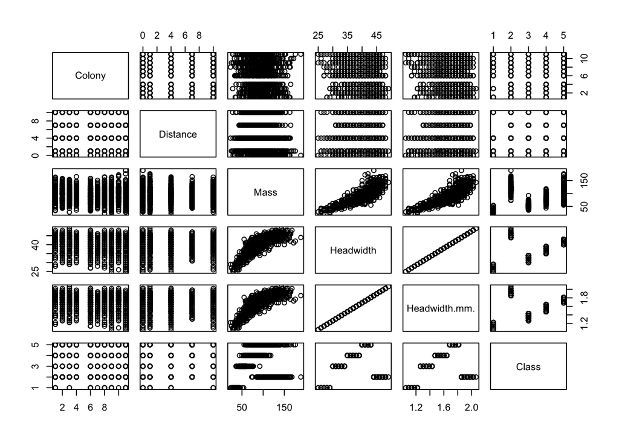

```r
ants <- read.table("thatch_ant_c5del.txt", sep='', header=TRUE)
pairs(ants)
```

> There is no explicit relationship between Headwidth and colony or distance.

### b

```r
ants2<-read.table("thatch_ant_c5del.txt", sep='', header=TRUE,
                  colClasses = c("factor","numeric","numeric","numeric","numeric"))
#should take colony number as factor

str(ants2)
```

```
## 'data.frame':    1104 obs. of  6 variables:
##  $ Colony       : Factor w/ 10 levels "1","10","11",..: 1 1 1 1 1 1 1 1 1 1 ...
##  $ Distance     : num  1 1 1 1 1 1 1 1 1 1 ...
##  $ Mass         : num  109 120 94 61 72 134 94 113 111 106 ...
##  $ Headwidth    : num  45 43 42 33 41 46 43 42 42 43 ...
##  $ Headwidth.mm.: num  1.9 1.81 1.77 1.39 1.73 ...
##  $ Class        : Factor w/ 5 levels "<30",">43","30-34",..: 2 5 5 3 5 2 5 5 5 5 ...
```

```r
result<-lm(Headwidth~0+Colony+Distance,data = ants2)
summary(result)
```

```
##
## Call:
## lm(formula = Headwidth ~ 0 + Colony + Distance, data = ants2)
##
## Residuals:
##                Min                 1Q             Median
## -14.05490008465392  -2.31778885140840   0.69894944968136
##                 3Q                Max
##   3.30228564245086   9.74771428434407
##
## Coefficients:
##                    Estimate         Std. Error  t value   Pr(>|t|)
## Colony1  40.627370229016130  0.468323702325208 86.75062 < 2.22e-16 ***
## Colony10 40.054900084653909  0.477132748207408 83.94917 < 2.22e-16 ***
## Colony11 38.146212626496670  0.465316330690553 81.97910 < 2.22e-16 ***
## Colony2  40.524917683525672  0.493002283728282 82.20026 < 2.22e-16 ***
## Colony3  39.084917683525688  0.493002283728282 79.27938 < 2.22e-16 ***
## Colony4  40.364502744764003  0.460772597466875 87.60179 < 2.22e-16 ***
## Colony6  38.899467304286460  0.434539585688822 89.51881 < 2.22e-16 ***
## Colony7  39.514585328490497  0.482656717552078 81.86892 < 2.22e-16 ***
## Colony8  39.788203674690223  0.502685948263432 79.15122 < 2.22e-16 ***
## Colony9  38.530753141789440  0.461801670431354 83.43572 < 2.22e-16 ***
## Distance  0.167368032130250  0.038568330948893  4.33952 1.5602e-05 ***
## ---
## Signif. codes:    0 '***' 0.001 '**' 0.01 '*' 0.050000000000000003 '.'
##   0.10000000000000001 ' ' 1
##
## Residual standard error: 4.5582011795398003 on 1093 degrees of freedom
## Multiple R-squared:  0.98752096240458,   Adjusted R-squared:  0.98739537282219
## F-statistic: 7863.0802303093 on 11 and 1093 DF,  p-value: < 2.22044604925e-16
```

```r
design<-model.matrix(~Colony+Distance-1,data = ants2)
dim(design)
```

```
## [1] 1104   11
```

```r
design[design[,11]==4
       ,colnames(design)=="Colony4"]
```

```
##  23  24  25  26  27  28  29  30  31  32  33  34  35  36  37  38  39  40
##   0   0   0   0   0   0   0   0   0   0   0   0   0   0   0   0   0   0
##  41  42  43  44  45  46  47  48  49  50  51  52  53  54  55  56  57 122
##   0   0   0   0   0   0   0   0   0   0   0   0   0   0   0   0   0   0
## 123 124 125 126 127 128 129 130 131 132 133 134 135 136 137 138 139 140
##   0   0   0   0   0   0   0   0   0   0   0   0   0   0   0   0   0   0
## 141 142 143 210 211 212 213 214 215 216 217 218 219 220 221 222 223 224
##   0   0   0   0   0   0   0   0   0   0   0   0   0   0   0   0   0   0
## 225 226 227 228 229 230 231 306 307 308 309 310 311 312 313 314 315 316
##   0   0   0   0   0   0   0   1   1   1   1   1   1   1   1   1   1   1
## 317 318 319 320 321 322 323 324 325 326 327 328 329 330 415 416 417 418
##   1   1   1   1   1   1   1   1   1   1   1   1   1   1   0   0   0   0
## 419 420 421 422 423 424 425 426 427 428 429 430 431 432 433 434 435 436
##   0   0   0   0   0   0   0   0   0   0   0   0   0   0   0   0   0   0
## 437 438 439 440 441 442 443 444 445 446 447 448 449 522 523 524 525 526
##   0   0   0   0   0   0   0   0   0   0   0   0   0   0   0   0   0   0
## 527 528 529 530 531 532 533 534 535 536 537 538 539 540 541 542 543 544
##   0   0   0   0   0   0   0   0   0   0   0   0   0   0   0   0   0   0
## 545 546 547 548 609 610 611 612 613 614 615 616 617 618 619 620 621 622
##   0   0   0   0   0   0   0   0   0   0   0   0   0   0   0   0   0   0
## 623 624 625 626 627 628 629 701 702 703 704 705 706 707 708 709 710 711
##   0   0   0   0   0   0   0   0   0   0   0   0   0   0   0   0   0   0
## 712 713 714 715 716 717 718 719 720 721 798 799 800 801 802 803 804 805
##   0   0   0   0   0   0   0   0   0   0   0   0   0   0   0   0   0   0
## 806 807 808 809 810 811 812 813 814 815 816 817 818 900 901 902 903 904
##   0   0   0   0   0   0   0   0   0   0   0   0   0   0   0   0   0   0
## 905 906 907 908 909 910 911 912 913 914 915 916 917 918 919 920 921 922
##   0   0   0   0   0   0   0   0   0   0   0   0   0   0   0   0   0   0
## 923 924
##   0   0
```

> the coefficients of the each colony means the average headwidth in that colony at distance 0. And the coefficient of distance means that the average headwidth will grow 0.167 per meter.

```r
m1<-lm(Headwidth~Colony+Distance-1,data = ants2)
m2<-lm(Headwidth~1,data = ants2)
anova(m1,m2)
```

```
## Analysis of Variance Table
##
## Model 1: Headwidth ~ Colony + Distance - 1
## Model 2: Headwidth ~ 1
##   Res.Df              RSS  Df         Sum of Sq       F     Pr(>F)
## 1   1093 22709.4774065221
## 2   1103 23847.3333333333 -10 -1137.85592681124 5.47646 5.6827e-08 ***
## ---
## Signif. codes:    0 '***' 0.001 '**' 0.01 '*' 0.050000000000000003 '.'
##   0.10000000000000001 ' ' 1
```

```r
m1<-lm(Headwidth~Colony+Distance-1,data = ants2)
m2<-lm(Headwidth~Colony-1,data = ants2)
anova(m1,m2)
```

```
## Analysis of Variance Table
##
## Model 1: Headwidth ~ Colony + Distance - 1
## Model 2: Headwidth ~ Colony - 1
##   Res.Df              RSS Df         Sum of Sq        F     Pr(>F)
## 1   1093 22709.4774065221
## 2   1094 23100.7417824617 -1 -391.264375939616 18.83143 1.5602e-05 ***
## ---
## Signif. codes:    0 '***' 0.001 '**' 0.01 '*' 0.050000000000000003 '.'
##   0.10000000000000001 ' ' 1
```

> H0: beta2=0  
> test statistic= $F=\frac{(RSS2-RSS1)/1}{RSS1/(1104-11)}=18.83143$. it’s distribution is F(1,1093), the result is to reject the Null hypothesis which means headwidth is related to distance.

### c

```r
library(lme4)
library(car)
m1<-lm(Headwidth~Colony+Distance-1,data = ants2)
m1$coefficients
rhs <- rep(0,9)
hm<-rbind(c(0,1,0,0,0,0,0,0,-1,0,0)
          ,c(1,-2,0,0,0,0,0,0,0,0,0)
          ,c(0,-2,1,0,0,0,0,0,0,0,0)
          ,c(0,-2,0,1,0,0,0,0,0,0,0)
          ,c(0,-2,0,0,1,0,0,0,0,0,0)
          ,c(0,-2,0,0,0,1,0,0,0,0,0)
          ,c(0,-2,0,0,0,0,1,0,0,0,0)
          ,c(0,-2,0,0,0,0,0,1,0,0,0)
          ,c(0,-2,0,0,0,0,0,0,0,1,0))
linearHypothesis(m1,hm,rhs)
```

[output not shown]

> we should reject null hypothesis.

### d

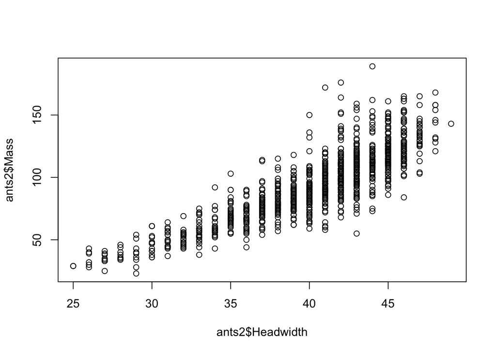

```r
plot(ants2$Headwidth,ants2$Mass)
```

```r
m1_e<-lm(Headwidth~Colony+Distance+Mass-1,data = ants2)
summary(m1_e)
```

```
##
## Call:
## lm(formula = Headwidth ~ Colony + Distance + Mass - 1, data = ants2)
##
## Residuals:
##              Min               1Q           Median               3Q
## -9.4943227071750 -1.4630029672001  0.0833239427996  1.5352005467690
##              Max
##  7.0764367285327
##
## Coefficients:
##                     Estimate          Std. Error  t value   Pr(>|t|)
## Colony1  26.9536307845344467  0.3469959861032736 77.67707 < 2.22e-16 ***
## Colony10 26.2465755402734828  0.3519234070243870 74.58036 < 2.22e-16 ***
## Colony11 25.4439095656268037  0.3334045755804524 76.31542 < 2.22e-16 ***
## Colony2  26.9479144111577220  0.3547484018748394 75.96346 < 2.22e-16 ***
## Colony3  25.9244311761678503  0.3495023446461054 74.17527 < 2.22e-16 ***
## Colony4  27.0170571779681197  0.3400203754510464 79.45717 < 2.22e-16 ***
## Colony6  26.5068203775475659  0.3181337603287494 83.31973 < 2.22e-16 ***
## Colony7  26.7464013150806004  0.3407208655307710 78.49945 < 2.22e-16 ***
## Colony8  26.8115216652756558  0.3508910857981444 76.40981 < 2.22e-16 ***
## Colony9  25.3888833006427710  0.3377277167921452 75.17560 < 2.22e-16 ***
## Distance  0.1262375434196212  0.0199122736649178  6.33969 3.3629e-10 ***
## Mass      0.1402413350202434  0.0025543455516245 54.90304 < 2.22e-16 ***
## ---
## Signif. codes:    0 '***' 0.001 '**' 0.01 '*' 0.050000000000000003 '.'
##   0.10000000000000001 ' ' 1
##
## Residual standard error: 2.3516675069870998 on 1092 degrees of freedom
## Multiple R-squared:  0.99668144951987,   Adjusted R-squared:  0.99664498193217
## F-statistic: 27330.610894499 on 12 and 1092 DF,  p-value: < 2.22044604925e-16
```

### e

```r
library(reshape2)
library(dplyr)
```

```r
library(ggplot2)

ants3<-read.table("thatch_ant_c5del.txt", sep='', header=TRUE,
                  colClasses=c("factor","factor","numeric","numeric","numeric"))

av1<-aov(Headwidth~Colony*Distance,data = ants3)#two factors

result<-model.tables(av1,type = "means")
interact<-result$tables$`Colony:Distance`
interact<-interact[c(3,10,7,5,8,9,2,6,4,1),]

inter<-matrix(as.vector(interact),nrow=10)
colnames(inter)<-colnames(interact);rownames(inter)<-rownames(interact)
inter<- as.data.frame(t(inter))

inter$distance<-rownames(inter)
inter<-melt(inter)
inter<-rename(inter,colony=variable,headwidth.mean=value)
plot.new()
```

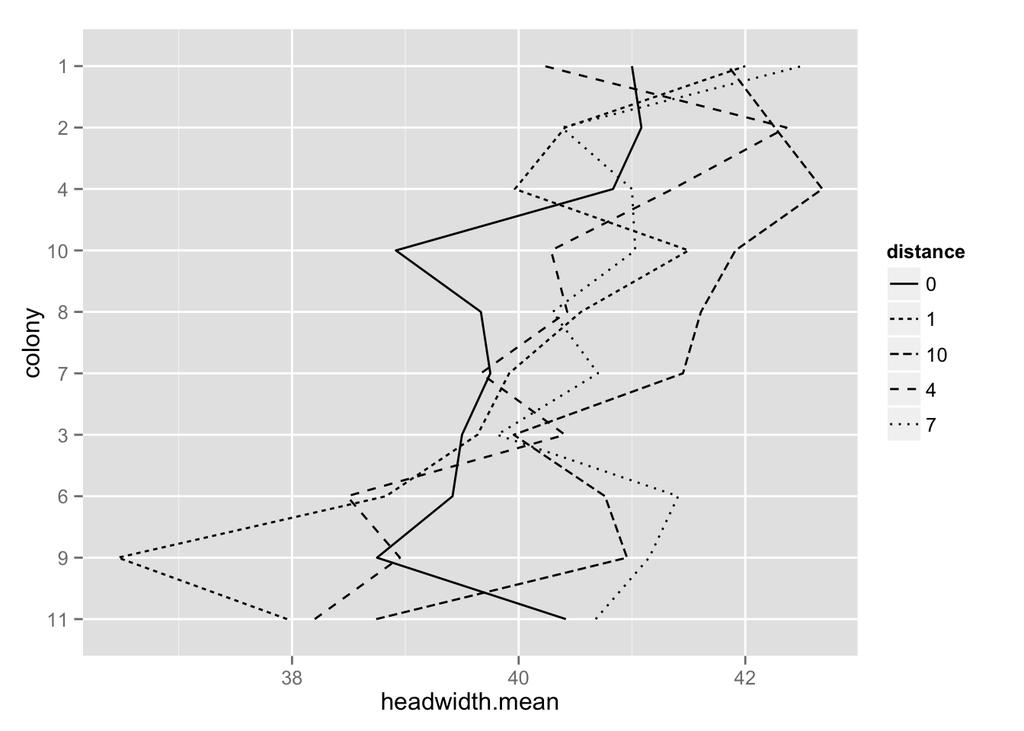

```r
ggplot(inter,aes(x =headwidth.mean,y=colony,group=distance)) + geom_path(aes(lty=distance))
```

> reproduce the plot of the problem.

```r
m1<-aov(Headwidth~Colony*Distance,data = ants3)
m2<-aov(Headwidth~1,data = ants3)
anova(m1,m2)
```

```
## Analysis of Variance Table
##
## Model 1: Headwidth ~ Colony * Distance
## Model 2: Headwidth ~ 1
##   Res.Df              RSS  Df         Sum of Sq       F     Pr(>F)
## 1   1054 21921.3659154694
## 2   1103 23847.3333333333 -49 -1925.96741786395 1.88984 0.00027006 ***
## ---
## Signif. codes:    0 '***' 0.001 '**' 0.01 '*' 0.050000000000000003 '.'
##   0.10000000000000001 ' ' 1
```

> H0:the effect of colony and distance is not significant.  
> result: reject the nul hypothesis, so the data supports the general observation from this plot.

> Another way to use variable distance: we can treat as not a factor but a normal variable into the model.

### f

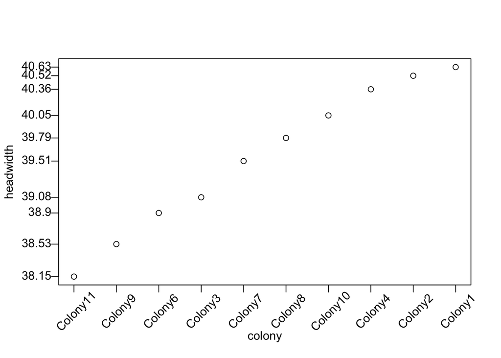

```r
m1<-lm(Headwidth~Colony+Distance-1,data = ants2)#one factors
result<-summary(m1)
interact<-result$coefficients[-11,1]
interact<-interact[c(3,10,7,5,8,9,2,6,4,1)]
inter<- as.data.frame((interact))
inter$colony<-rownames(inter)
colnames(inter)[1]<-"headwidth.mean"
inter<-arrange(inter,headwidth.mean)

plot(inter$headwidth.mean,axes = F,xlab="colony",ylab="headwidth")

lablist.x<-inter$colony
lablist.y<-inter$headwidth.mean
axis(1, at=seq(1, 10, by=1), labels = FALSE)

text(x = seq(1, 10, by=1), par("usr")[3] - 0.2, labels = lablist.x, srt = 45, pos = 1, xpd = TRUE)

axis(2, at=inter$headwidth.mean, labels = FALSE)

text(y=inter$headwidth.mean, par("usr")[1], labels = round(lablist.y,2), pos = 2, xpd = TRUE)
box()
```

```r
m1<-lm(Headwidth~Colony+Distance-1,data = ants2)
m2<-lm(Headwidth~1,data = ants2)
anova(m1,m2)
```

```
## Analysis of Variance Table
##
## Model 1: Headwidth ~ Colony + Distance - 1
## Model 2: Headwidth ~ 1
##   Res.Df              RSS  Df         Sum of Sq       F     Pr(>F)
## 1   1093 22709.4774065221
## 2   1103 23847.3333333333 -10 -1137.85592681124 5.47646 5.6827e-08 ***
## ---
## Signif. codes:    0 '***' 0.001 '**' 0.01 '*' 0.050000000000000003 '.'
##   0.10000000000000001 ' ' 1
```

# 7

> no data on the dropbox

### a&b

```r
library(car)
DataURL <- "http://www.stat.wisc.edu/~st849-1/data/"
str(ql <- read.table(paste(DataURL, "hmw3q1_data.txt", sep=""), header=TRUE))
```

```
## 'data.frame':    48 obs. of  2 variables:
##  $ GSS: num  4 13.4 7.4 2.7 13.5 10.3 11.7 4.5 14.3 5.8 ...
##  $ VL : int  40406 2603 55246 22257 400 95505 5537 3205 90 12394 ...
```

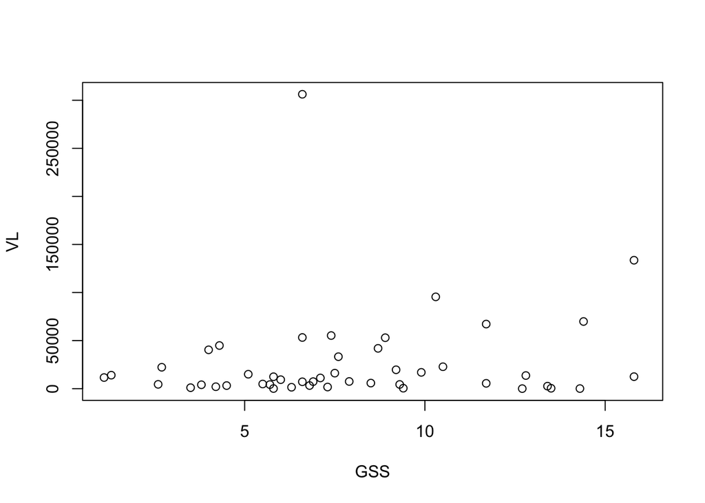

```r
plot(ql)
```

```r
outlierTest(lm(VL~GSS,data = ql))
```

```
##              rstudent unadjusted p-value           Bonferonni p
## 28 10.584279549417912         1.1262e-13 5.2930999999999997e-12
```

```r
outlierTest(lm(VL~GSS,data = ql[-28,]))
```

```
##              rstudent     unadjusted p-value          Bonferonni p
## 16 4.4996439861964017 5.1131000000000002e-05 0.0023519999999999999
```

```r
outlierTest(lm(VL~GSS,data = ql[-c(16,28),]))
```

```
##            rstudent     unadjusted p-value         Bonferonni p
## 6 3.907709169616659 0.00033307999999999998 0.014989000000000001
```

```r
outlierTest(lm(VL~GSS,data = ql[-c(6,16,28),]))
```

```
##
## No Studentized residuals with Bonferonni p < 0.050000000000000003
## Largest |rstudent|:
##              rstudent    unadjusted p-value        Bonferonni p
## 44 2.8884453793703928 0.0061574000000000004 0.27091999999999999
```

```r
outlierTest(lm(VL~GSS,data = ql[-c(6,16,28,44),]))
```

```
##
## No Studentized residuals with Bonferonni p < 0.050000000000000003
## Largest |rstudent|:
##              rstudent unadjusted p-value         Bonferonni p
## 21 3.3229078831048207          0.0019123 0.082226999999999995
```

```r
model<-lm(VL~GSS,data = ql[-c(6,16,28),])
summary(model)
```

```
##
## Call:
## lm(formula = VL ~ GSS, data = ql[-c(6, 16, 28), ])
##
## Residuals:
##               Min                1Q            Median                3Q
## -20544.4703669918 -12787.4039684058  -8729.0317712772   2756.1960958608
##               Max
##  49173.6099165087
##
## Coefficients:
##                      Estimate        Std. Error t value Pr(>|t|)
## (Intercept) 11779.95090755877  6899.95902292302 1.70725 0.095159 .
## GSS           619.19716499531   811.54292396476 0.76299 0.449735
## ---
## Signif. codes:    0 '***' 0.001 '**' 0.01 '*' 0.050000000000000003 '.'
##   0.10000000000000001 ' ' 1
##
## Residual standard error: 19460.438736979999 on 42 degrees of freedom
##   (1 observation deleted due to missingness)
## Multiple R-squared:  0.013671222197528,  Adjusted R-squared:  -0.0098127963215788
## F-statistic: 0.58215003477385 on 1 and 42 DF,  p-value: 0.44973525666658
```

### c

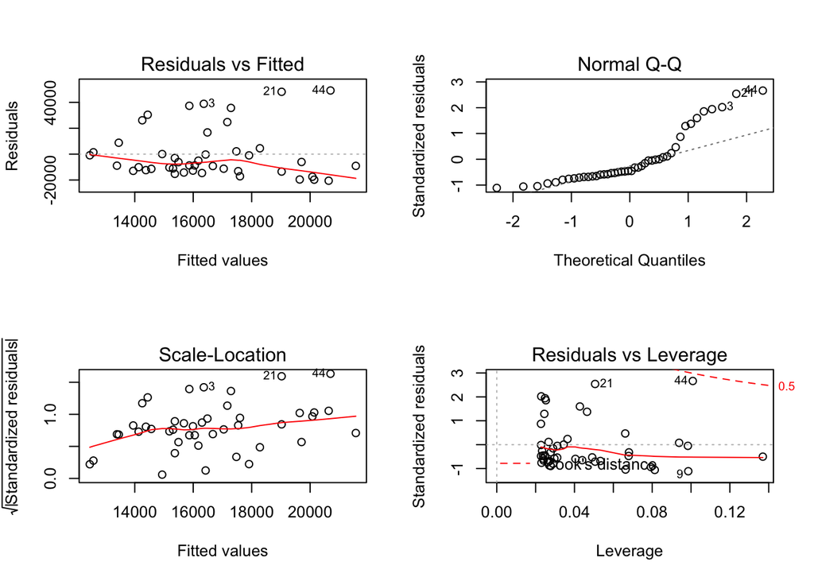

```r
par(mfrow=c(2,2))
plot(model,ask = FALSE)
```

>it seems that constant variance and normality assumption are both violated.

### d

```r
b<-boxCox(VL~GSS,data=ql,lambda = seq(-2, 2, 1/10) )
```

[figure not shown]

```r
lambda<- b$x[which.max(b$y)]
ql$y<-(ql$VL^lambda-1)/lambda
model2<-lm(y~GSS,data = ql)
summary(model2)
```

```
##
## Call:
## lm(formula = y ~ GSS, data = ql)
##
## Residuals:
##                Min                 1Q             Median
## -14.26274654425964  -3.38560545171216   0.41149621782945
##                 3Q                Max
##   4.04458689602684  16.21973480377125
##
## Coefficients:
##                       Estimate         Std. Error t value   Pr(>|t|)
## (Intercept) 18.696884638374907  2.212235627207622 8.45158 7.6605e-11 ***
## GSS          0.032167668241144  0.253477493745932 0.12691    0.89958
## ---
## Signif. codes:    0 '***' 0.001 '**' 0.01 '*' 0.050000000000000003 '.'
##   0.10000000000000001 ' ' 1
##
## Residual standard error: 6.4461075959493996 on 45 degrees of freedom
##   (1 observation deleted due to missingness)
## Multiple R-squared:  0.00035776054075995,    Adjusted R-squared:  -0.021856511447223
## F-statistic: 0.01610498606272 on 1 and 45 DF,  p-value: 0.89958062788812
```

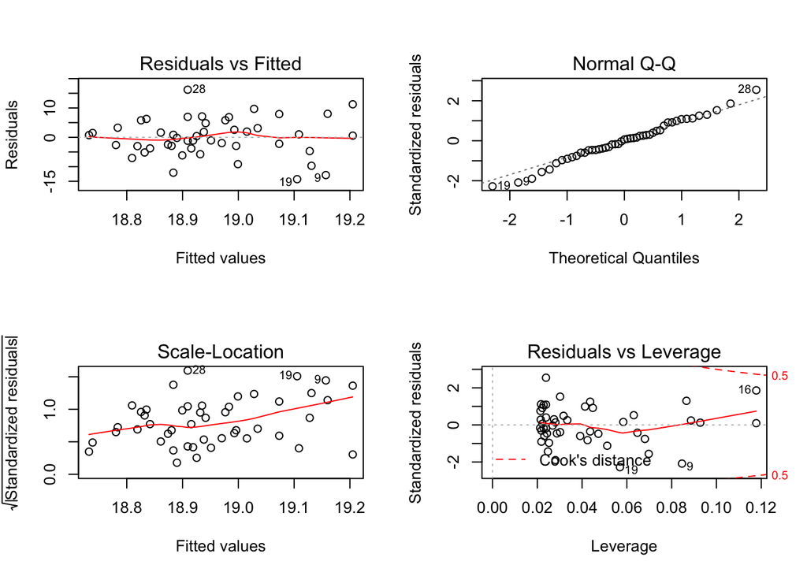

```r
par(mfrow=c(2,2))
plot(model2,ask = FALSE)
```

# 8

### a

```r
str(br <- read.table("brand_preference.txt", sep="", header=TRUE))
```

```
## 'data.frame':    16 obs. of  3 variables:
##  $ Brand_Liking    : num  64 73 61 76 72 80 71 83 83 89 ...
##  $ Moisture_Content: num  4 4 4 4 6 6 6 6 8 8 ...
##  $ Sweetness       : num  2 4 2 4 2 4 2 4 2 4 ...
```

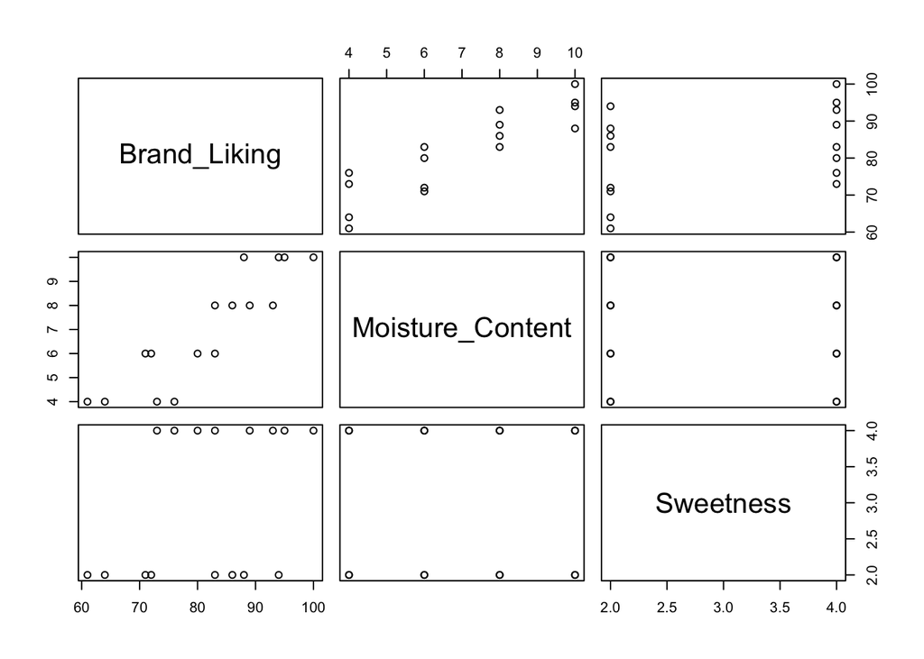

```r
pairs(br)
```

### b

```r
model<-lm(Brand_Liking~Moisture_Content+Sweetness,data = br)
summary(model)
```

```
##
## Call:
## lm(formula = Brand_Liking ~ Moisture_Content + Sweetness, data = br)
##
## Residuals:
##     Min      1Q  Median      3Q     Max
## -4.4000 -1.7625  0.0250  1.5875  4.2000
##
## Coefficients:
##                           Estimate        Std. Error  t value   Pr(>|t|)
## (Intercept)      37.65000000000001  2.99610323843899 12.56632 1.1996e-08
## Moisture_Content  4.42500000000000  0.30111970530518 14.69515 1.7780e-09
## Sweetness         4.37500000000000  0.67332413042708  6.49761 2.0110e-05
##
## (Intercept)      ***
## Moisture_Content ***
## Sweetness        ***
## ---
## Signif. codes:    0 '***' 0.001 '**' 0.01 '*' 0.050000000000000003 '.'
##   0.10000000000000001 ' ' 1
##
## Residual standard error: 2.6932965217082998 on 13 degrees of freedom
## Multiple R-squared:  0.95205897305541,   Adjusted R-squared:  0.94468343044855
## F-statistic: 129.08324496288 on 2 and 13 DF,  p-value: 2.658261267082e-09
```

> keep sweetness equal, the average increase of brand_liking score is 4.43.

### c

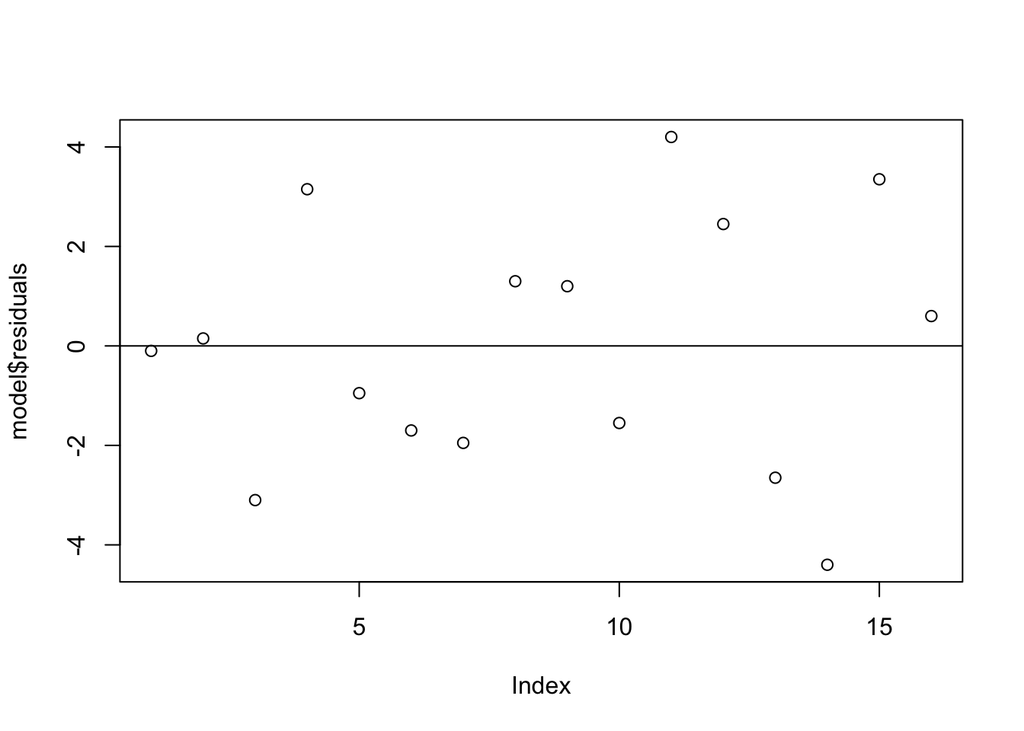

```r
par(mfrow=c(1,1))
plot(model$residuals)
abline(h=mean(model$residuals))#E(e)=0
```

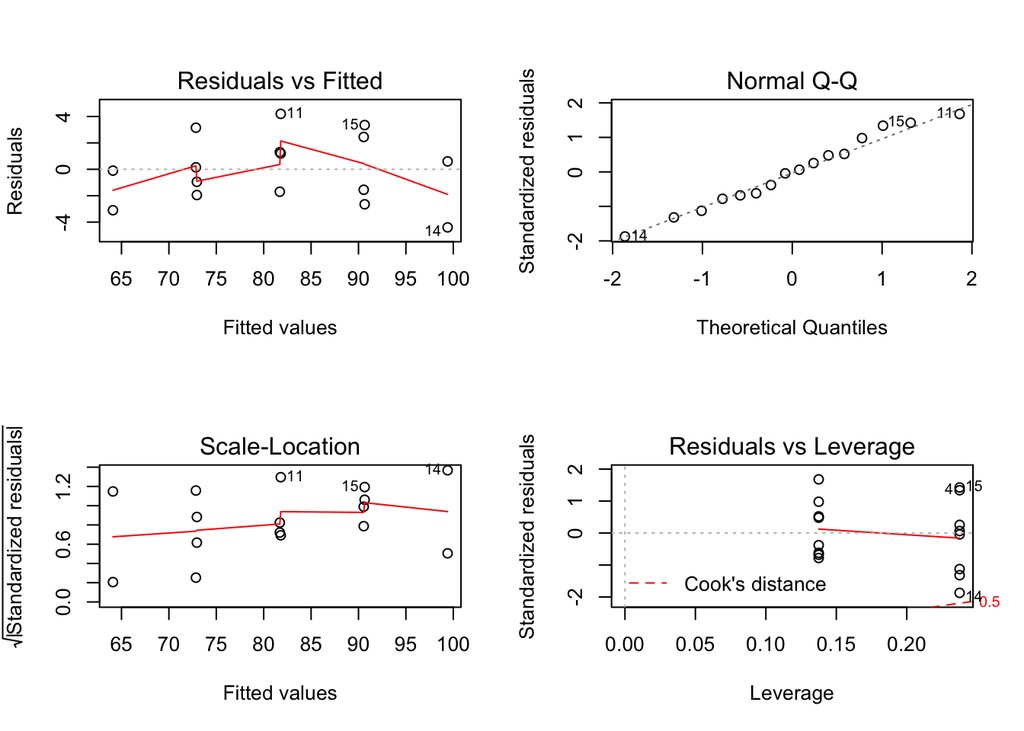

```r
par(mfrow=c(2,2))
plot(model,ask=FALSE)
```

> it seems the model satisfy the Gauss-Markov assumption.

### d

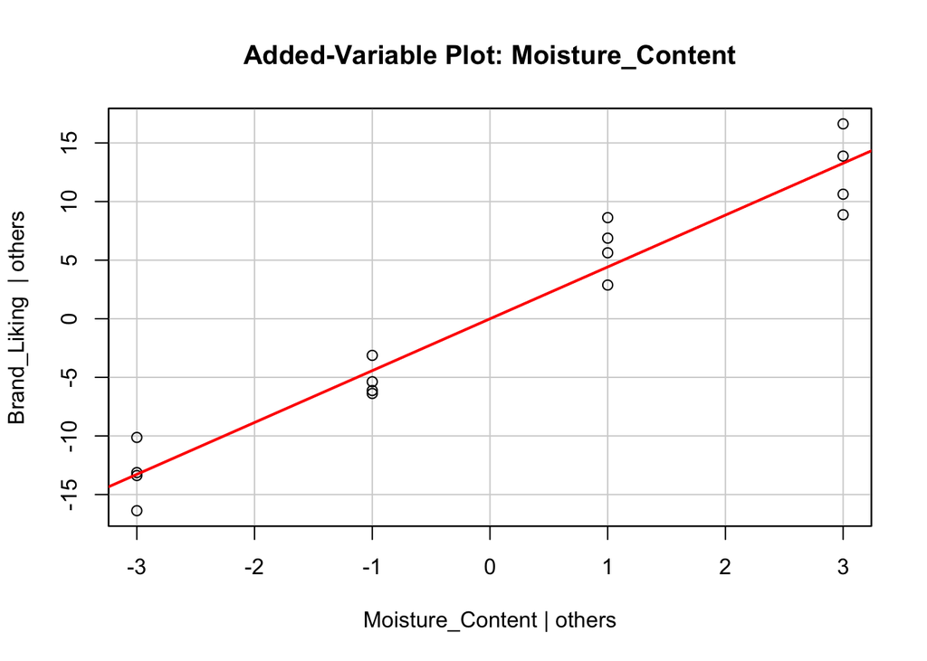

```r
library(car)
avPlot(model,"Moisture_Content")
```

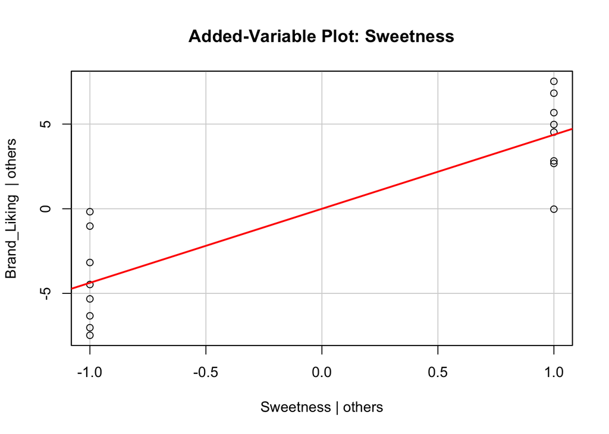

```r
avPlot(model,"Sweetness")
```

### e

> According to the added-variable plot, the model in part b is appropriate that both variables are important.

### f

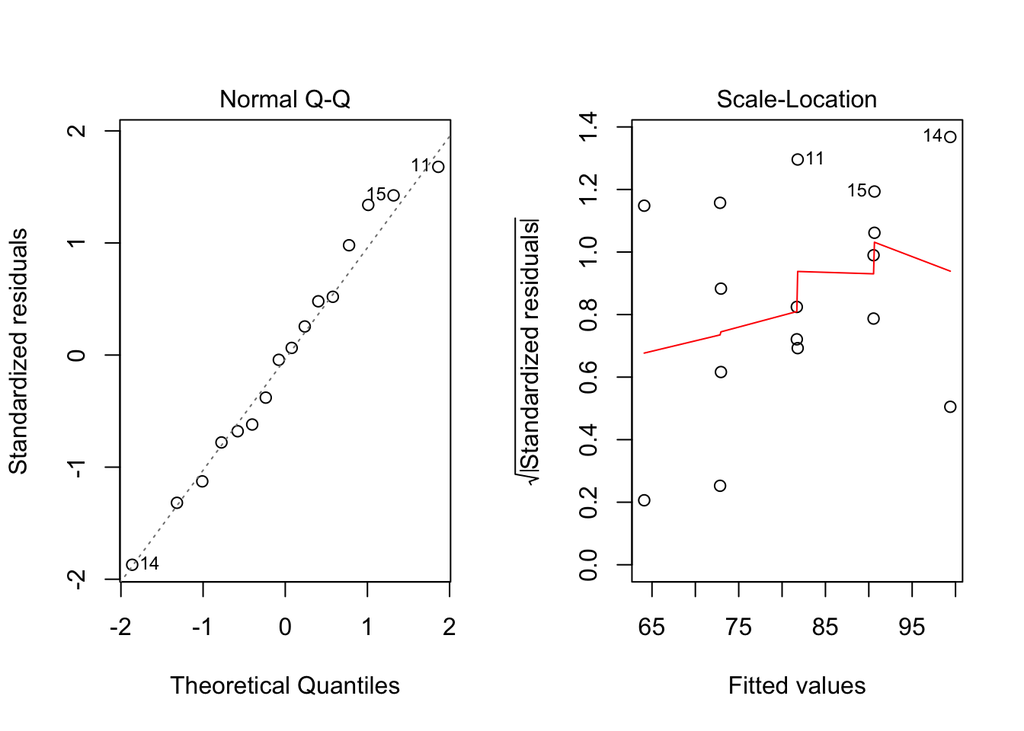

```r
layout(matrix(1:2,ncol=2))
plot(model,which=c(2,3))
```

```r
ext_sr<- rstudent(model)#t(16-3-1)
# which(abs(ext_sr)>2)
(1-pt(abs(ext_sr),df = 16-3-1))<0.1/2#the true are the outliers
```

```
##     1     2     3     4     5     6     7     8     9    10    11    12
## FALSE FALSE FALSE FALSE FALSE FALSE FALSE FALSE FALSE FALSE  TRUE FALSE
##    13    14    15    16
## FALSE  TRUE FALSE FALSE
```

> the desicion rule is that if the absolute value of external residual is larger than the critical value(but i use p value instead), we should take it as the outlier. The result shows that the outliers are the 11th and 14th points.

### g

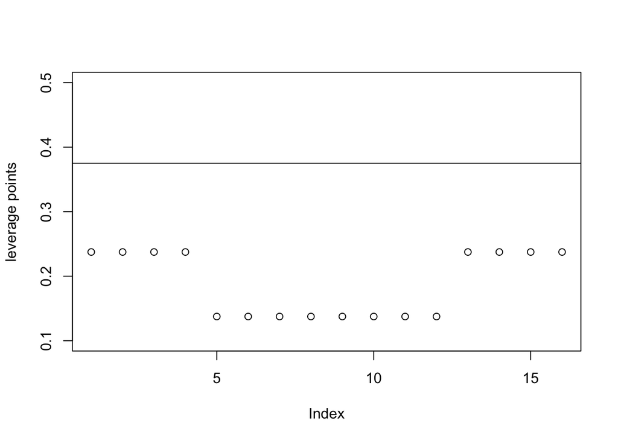

```r
par(mfrow=c(1,1))
x<-model.matrix(model)
lev<-hat(x)
plot(lev,ylim = c(0.1,0.5),ylab = "leverage points")
abline(h=(2*3)/16)
```

> there is no leverage point.

### h

```r
e<-diag(model$residuals)
h<-diag(1/(1-hat(x)))
H<-x%*%solve(t(x)%*%x)%*%t(x)
(cooks<-apply(((h%*%e%*%H)^2)/(3*var(br$Brand_Liking)),1,sum))
```

```
##  [1] 1.0383638555377820e-05 2.3363186749601975e-05 9.9786766517192677e-03
##  [4] 1.0303165356574837e-02 4.2403074377726145e-04 1.3578380604058523e-03
##  [7] 1.7865672057762159e-03 7.9402986923387208e-04 6.7656982940637498e-04
## [10] 1.1287909827422343e-03 8.2879804102281018e-03 2.8202155562581763e-03
## [13] 7.2919101755149077e-03 2.0102724243213781e-02 1.1653038368774089e-02
## [16] 3.7381098799364547e-04
```

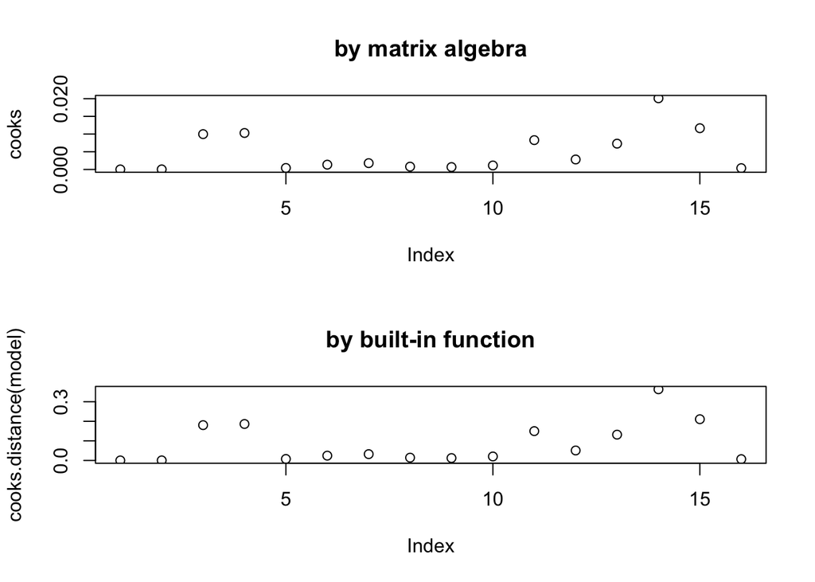

```r
par(mfrow=c(2,1))
plot(cooks,main = "by matrix algebra")
plot(cooks.distance(model),main = "by built-in function")
```

# 9

### a

```r
str(hayfever <- within(read.table("hayfever.txt", sep="", header = TRUE),
{
 A <- factor(A)
 B <- factor(B)
 id <- factor(id)
}))
```

```
## 'data.frame':    36 obs. of  4 variables:
##  $ hours: num  2.4 2.7 2.3 2.5 4.6 4.2 4.9 4.7 4.8 4.5 ...
##  $ A    : Factor w/ 3 levels "1","2","3": 1 1 1 1 1 1 1 1 1 1 ...
##  $ B    : Factor w/ 3 levels "1","2","3": 1 1 1 1 2 2 2 2 3 3 ...
##  $ id   : Factor w/ 4 levels "1","2","3","4": 1 2 3 4 1 2 3 4 1 2 ...
```

```r
model1<-aov(hours~A*B,data = hayfever)
(effect<-model.tables(model1))
```

```
## Tables of effects
##
##  A
## A
##                    1                    2                    3
## -3.29999999999999982  0.65000000000000002  2.64999999999999991
##
##  B
## B
##                   1                   2                   3
## -2.5499999999999998  0.7500000000000000  1.8000000000000000
##
##  A:B
##    B
## A   1                     2                     3
##   1  1.141699999999999937 -0.033300000000000003 -1.108300000000000063
##   2  0.166699999999999987  0.341700000000000004 -0.508299999999999974
##   3 -1.308300000000000018 -0.308300000000000018  1.616700000000000026
```

```r
(means<-model.tables(model1,type = "means"))
```

```
## Tables of means
## Grand mean
##
## 7.1833333333333318
##
##  A
## A
##                  1                  2                  3
## 3.8830000000000000 7.8330000000000002 9.8330000000000002
##
##  B
## B
##                  1                  2                  3
## 4.6330000000000000 7.9329999999999998 8.9830000000000005
##
##  A:B
##    B
## A   1                   2                   3
##   1  2.4750000000000001  4.5999999999999996  4.5750000000000002
##   2  5.4500000000000002  8.9250000000000007  9.1250000000000000
##   3  5.9749999999999996 10.2750000000000004 13.2500000000000000
```

```r
7.1833+0.65+1.8-0.5083
```

```
## [1] 9.125
```

> since the model is $Y=\mu + \alpha + \beta +(\alpha * \beta)+\epsilon$ from the table we can see that when factor A=2 and factor B=3, the estimated mean is about 9.125.

### b

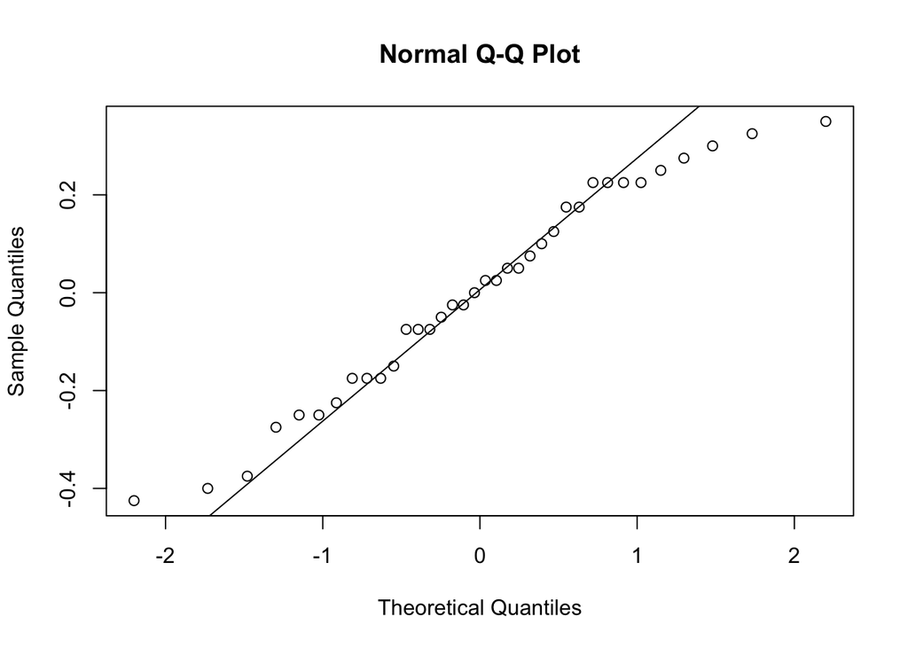

```r
qqnorm(model1$residuals)
qqline(model1$residuals)
```

Apparently, it violate the nomality assumption.

### c

```r
levels(hayfever$A)
```

```
## [1] "1" "2" "3"
```

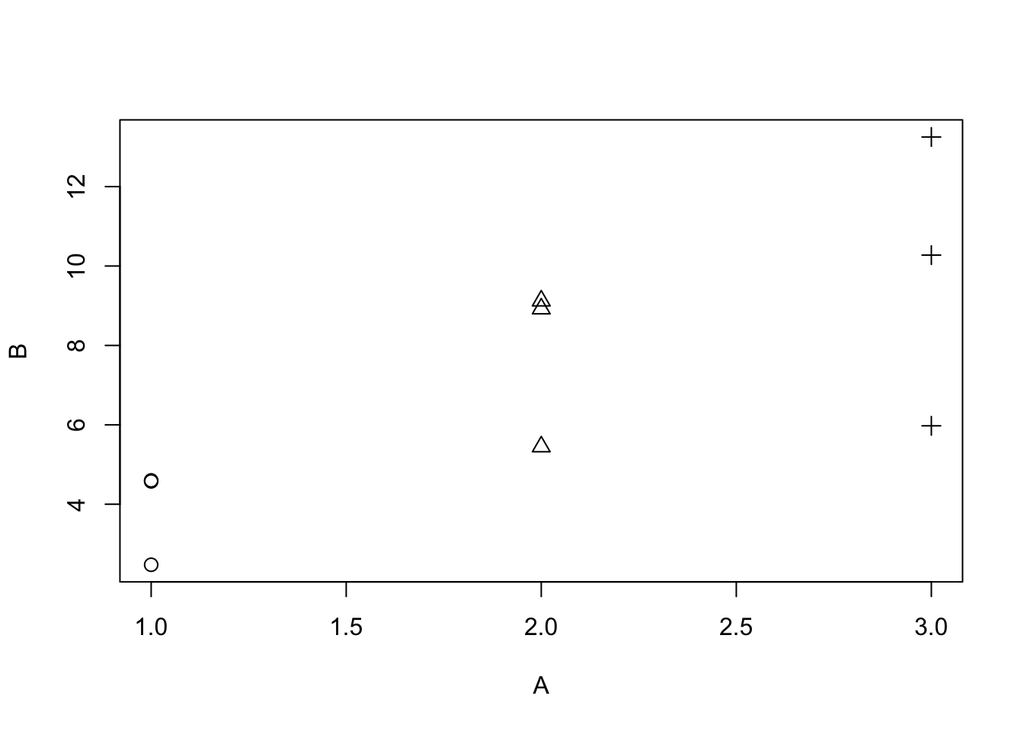

```r
x<-rep(1:3,3)
y<-as.vector(means$tables$`A:B`)
plot(x,y,pch=1:3,cex=1.2,xlab = "A",ylab = "B")
```

>apparently, there is interaction between A AND B.

### d&e

```r
summary(model1)
```

```
##             Df  Sum Sq          Mean Sq    F value     Pr(>F)
## A            2 220.020 110.010000000000 1827.85846 < 2.22e-16 ***
## B            2 123.660  61.830000000000 1027.32923 < 2.22e-16 ***
## A:B          4  29.425   7.356250000000  122.22692 < 2.22e-16 ***
## Residuals   27   1.625   0.060185185185
## ---
## Signif. codes:    0 '***' 0.001 '**' 0.01 '*' 0.050000000000000003 '.'
##   0.10000000000000001 ' ' 1
```

```r
model2<-aov(hours~A+B,data = hayfever)
anova(model1,model2)
```

```
## Analysis of Variance Table
##
## Model 1: hours ~ A * B
## Model 2: hours ~ A + B
##   Res.Df    RSS Df Sum of Sq         F     Pr(>F)
## 1     27  1.625
## 2     31 31.050 -4   -29.425 122.22692 < 2.22e-16 ***
## ---
## Signif. codes:    0 '***' 0.001 '**' 0.01 '*' 0.050000000000000003 '.'
##   0.10000000000000001 ' ' 1
```

> they are significant at level of 0.05.